# Final Project

Bhabika Joshi

2023-05-02

# 1 Introduction

The categorization of school districts in the United States is important, as it can impact the funding that schools get, the number of students in these schools, and the overall resources that are provided to the districts and individual schools. Smaller areas such as rural or micropolitan districts may have higher per-pupil human capital cost (Dhaliwal & Bruno, 2021) and therefore see differences in funding levels which can have implications for policy and practice. A model that can predict type of district based on various independent variables such as disability or economic status could help lead policymakers and financial bureaucracies in investing federal funds into the districts that need the funding the most.

## 1.1 The Data

The following data set lists various metro and micro counties in the USA and of these counties, describes average test scores for economically and non-economically disadvantaged students, % of students by race, language status, and disability diagnosis, total enrollment of students from Grades 3-8, and % of population of people with bachelors or higher, % unemployed, and % impoverished.

- **Source** = The data were gathered from the Stanford Education Data Archive (SEDA). The metro/micro ID and names were gathered from the 2017-2021 Statistics of U.S. Businesses at census.gov. Information about percentage of each race in the grade and achieve data was collected from the Common Core of Data (CCD) and the EDFacts data system housed by the U.S. Department of Education (Fahle et al., 2021; Reardon et al., 2022).
- **Sample Size** = The sample size is 933 metro and micro counties in the USA.
- **Outcome Variable** = The outcome variable is the binary variable: metro or micro district. Metropolitan districts contain a population of 50,000 or more people, while micropolitan districts have populations less than 50,000 but more than 10,000 people (Federal Reserve System, 2023).
- **Predictor Variables** = The predictor variables are average test scores, economic status, disability diagnosis, and language status (English Language Learner).
- **Individual Differences** = Individual differences in the samples can be seen in a variety of ways, including disability, economic, and linguistic status.
- **Demographics** = The demographics of the population are listed according to economic status (economically disadvantaged or not, population in poverty, etc.), disability diagnosis (identified as special education), language status (ELL), and average test scores from 3rd to 8th graders in those districts.

## 1.2 Research Question

1. Can components derived from the SEDA data set using a PCA predict whether 3rd to 8th graders live in micropolitan or metropolitan districts in the United States?

# 2 Basics

First, clear memory and bring in the packages we need.

```r
rm(list=ls(all=TRUE))
library(tidyverse) #call in tidyverse #data science
library(dplyr) #call in dplyr #data manipulation
```

## 2.1 Call in Data

```r
data <- read_csv("LearningAnalysticsdataset.csv", show_col_types = FALSE) #Bring in the CSV file
str(data) #Check the structure to make sure our variables are correctly identified as "character" or "numeric"
```

```
## spc_tbl_ [933 × 19] (S3: spec_tbl_df/tbl_df/tbl/data.frame)
##  $ sedametro     : num [1:933] 10100 10140 10180 10220 10300 ...
##  $ sedametroname : chr [1:933] "Aberdeen, SD" "Aberdeen, WA" "Abilene, TX" "Ada, OK" ...
##  $ avg_test_all  : num [1:933] 0.21221 -0.23448 0.00239 -0.08299 -0.04656 ...
##  $ avg_test_ecd  : num [1:933] -0.049 -0.41 -0.259 -0.265 -0.266 ...
##  $ avg_test_nec  : num [1:933] 0.3517 0.0985 0.3419 0.1902 0.1167 ...
##  $ metro_or_micro: chr [1:933] "Micro" "Micro" "Metro" "Micro" ...
##  $ perurban      : num [1:933] 0 0 65.6 0 0 ...
##  $ perell        : num [1:933] 2.104 5.409 2.745 1.848 0.286 ...
##  $ perspeced     : num [1:933] 14.3 15 11 16 13.3 ...
##  $ pernam        : num [1:933] 5.125 6.783 0.415 37.138 0.42 ...
##  $ perasn        : num [1:933] 1.588 1.448 1.528 0.659 0.54 ...
##  $ perhsp        : num [1:933] 2.72 18.64 33.68 6.58 9.01 ...
##  $ perblk        : num [1:933] 1.62 1.12 8.67 2.56 1.71 ...
##  $ perwht        : num [1:933] 88.9 72 55.7 53.1 88.3 ...
##  $ perecd        : num [1:933] 41.3 62.6 56.7 59.9 42.2 ...
##  $ totenrl       : num [1:933] 2720 4706 12618 3020 5653 ...
##  $ perbaplus     : num [1:933] 26.2 15 21.6 26.5 19.9 ...
##  $ perunemp      : num [1:933] 2.43 9.69 4.67 5.47 7.4 ...
##  $ perpoverty    : num [1:933] 11.3 15.9 15.7 17.8 12.2 ...
##  - attr(*, "spec")=
##   .. cols(
##   ..   sedametro = col_double(),
##   ..   sedametroname = col_character(),
##   ..   avg_test_all = col_double(),
##   ..   avg_test_ecd = col_double(),
##   ..   avg_test_nec = col_double(),
##   ..   metro_or_micro = col_character(),
##   ..   perurban = col_double(),
##   ..   perell = col_double(),
##   ..   perspeced = col_double(),
##   ..   pernam = col_double(),
##   ..   perasn = col_double(),
##   ..   perhsp = col_double(),
##   ..   perblk = col_double(),
##   ..   perwht = col_double(),
##   ..   perecd = col_double(),
##   ..   totenrl = col_double(),
##   ..   perbaplus = col_double(),
##   ..   perunemp = col_double(),
##   ..   perpoverty = col_double()
##   .. )
##  - attr(*, "problems")=<externalptr>
```

## 2.2 Data Wrangling

This SEDA data set has some level of data cleaning already. There are no NAs or missing data. Still, I removed the first two columns from the data set since the ID and name of the districts are not applicable for the analysis. The variable accounting for percentage of urban population in the district was also removed to avoid redundancy when creating a prediction model. All other variables were kept for the analysis. I also renamed the variables of interest in the data set so they look cleaner for our analysis.

```r
data_pca <- data[,c(3:6, 8:19)] #I only want to analyze my variables of interest

#rename the variables using the dplyr package
data_pca <- data_pca %>% rename(Average_Test_Scores = avg_test_all, Average_Scores_EcoDisadvantaged = avg_test_ecd, Average_Scores_NotEcoDisadvantaged = avg_test_nec, Metro_or_Micro = metro_or_micro, Percent_English_Language_Learner = perell, Percent_Special_Education = perspeced, Percent_NativeAmerican = pernam, Percent_Asian = perasn, Percent_Hispanic = perhsp, Percent_Black = perblk, Percent_White = perwht, Percent_EcoDisadvantaged = perecd, Total_Enrollment = totenrl, Percent_Bachelors = perbaplus, Percent_Unemployed = perunemp, Population_Poverty = perpoverty)

str(data_pca)
```

```
## tibble [933 × 16] (S3: tbl_df/tbl/data.frame)
##  $ Average_Test_Scores               : num [1:933] 0.21221 -0.23448 0.00239 -0.08299 -0.04656 ...
##  $ Average_Scores_EcoDisadvantaged   : num [1:933] -0.049 -0.41 -0.259 -0.265 -0.266 ...
##  $ Average_Scores_NotEcoDisadvantaged: num [1:933] 0.3517 0.0985 0.3419 0.1902 0.1167 ...
##  $ Metro_or_Micro                    : chr [1:933] "Micro" "Micro" "Metro" "Micro" ...
##  $ Percent_English_Language_Learner  : num [1:933] 2.104 5.409 2.745 1.848 0.286 ...
##  $ Percent_Special_Education         : num [1:933] 14.3 15 11 16 13.3 ...
##  $ Percent_NativeAmerican            : num [1:933] 5.125 6.783 0.415 37.138 0.42 ...
##  $ Percent_Asian                     : num [1:933] 1.588 1.448 1.528 0.659 0.54 ...
##  $ Percent_Hispanic                  : num [1:933] 2.72 18.64 33.68 6.58 9.01 ...
##  $ Percent_Black                     : num [1:933] 1.62 1.12 8.67 2.56 1.71 ...
##  $ Percent_White                     : num [1:933] 88.9 72 55.7 53.1 88.3 ...
##  $ Percent_EcoDisadvantaged          : num [1:933] 41.3 62.6 56.7 59.9 42.2 ...
##  $ Total_Enrollment                  : num [1:933] 2720 4706 12618 3020 5653 ...
##  $ Percent_Bachelors                 : num [1:933] 26.2 15 21.6 26.5 19.9 ...
##  $ Percent_Unemployed                : num [1:933] 2.43 9.69 4.67 5.47 7.4 ...
##  $ Population_Poverty                : num [1:933] 11.3 15.9 15.7 17.8 12.2 ...
```

## 2.3 Check for Multicollinearity

```r
#check for multicollinearity

data_corr <- data_pca[, c(1:3, 5:16)] #create a tibble of the predictor variables
#remove metro/micro for correlation analysis
str(data_corr)
```

```
## tibble [933 × 15] (S3: tbl_df/tbl/data.frame)
##  $ Average_Test_Scores               : num [1:933] 0.21221 -0.23448 0.00239 -0.08299 -0.04656 ...
##  $ Average_Scores_EcoDisadvantaged   : num [1:933] -0.049 -0.41 -0.259 -0.265 -0.266 ...
##  $ Average_Scores_NotEcoDisadvantaged: num [1:933] 0.3517 0.0985 0.3419 0.1902 0.1167 ...
##  $ Percent_English_Language_Learner  : num [1:933] 2.104 5.409 2.745 1.848 0.286 ...
##  $ Percent_Special_Education         : num [1:933] 14.3 15 11 16 13.3 ...
##  $ Percent_NativeAmerican            : num [1:933] 5.125 6.783 0.415 37.138 0.42 ...
##  $ Percent_Asian                     : num [1:933] 1.588 1.448 1.528 0.659 0.54 ...
##  $ Percent_Hispanic                  : num [1:933] 2.72 18.64 33.68 6.58 9.01 ...
##  $ Percent_Black                     : num [1:933] 1.62 1.12 8.67 2.56 1.71 ...
##  $ Percent_White                     : num [1:933] 88.9 72 55.7 53.1 88.3 ...
##  $ Percent_EcoDisadvantaged          : num [1:933] 41.3 62.6 56.7 59.9 42.2 ...
##  $ Total_Enrollment                  : num [1:933] 2720 4706 12618 3020 5653 ...
##  $ Percent_Bachelors                 : num [1:933] 26.2 15 21.6 26.5 19.9 ...
##  $ Percent_Unemployed                : num [1:933] 2.43 9.69 4.67 5.47 7.4 ...
##  $ Population_Poverty                : num [1:933] 11.3 15.9 15.7 17.8 12.2 ...
```

```r
cor(data_corr) #check correlation
```

```
##                                    Average_Test_Scores
## Average_Test_Scores                         1.00000000
## Average_Scores_EcoDisadvantaged             0.82324762
## Average_Scores_NotEcoDisadvantaged          0.86141492
## Percent_English_Language_Learner           -0.22973325
## Percent_Special_Education                   0.20413507
## Percent_NativeAmerican                     -0.16758650
## Percent_Asian                               0.12252636
## Percent_Hispanic                           -0.31246936
## Percent_Black                              -0.43084760
## Percent_White                               0.59224698
## Percent_EcoDisadvantaged                   -0.78823246
## Total_Enrollment                            0.06824773
## Percent_Bachelors                           0.48622752
## Percent_Unemployed                         -0.59228074
## Population_Poverty                         -0.56565454
##                                    Average_Scores_EcoDisadvantaged
## Average_Test_Scores                                     0.82324762
## Average_Scores_EcoDisadvantaged                         1.00000000
## Average_Scores_NotEcoDisadvantaged                      0.64647631
## Percent_English_Language_Learner                       -0.24016866
## Percent_Special_Education                               0.23164534
## Percent_NativeAmerican                                 -0.10512880
## Percent_Asian                                          -0.13175444
## Percent_Hispanic                                       -0.24549979
## Percent_Black                                          -0.43656332
## Percent_White                                           0.55892141
## Percent_EcoDisadvantaged                               -0.42283802
## Total_Enrollment                                       -0.08358215
## Percent_Bachelors                                       0.05483363
## Percent_Unemployed                                     -0.39922240
## Population_Poverty                                     -0.31053692
##                                    Average_Scores_NotEcoDisadvantaged
## Average_Test_Scores                                        0.86141492
## Average_Scores_EcoDisadvantaged                            0.64647631
## Average_Scores_NotEcoDisadvantaged                         1.00000000
## Percent_English_Language_Learner                          -0.07100577
## Percent_Special_Education                                  0.10494895
## Percent_NativeAmerican                                    -0.17990341
## Percent_Asian                                              0.19222798
```

[output cut: 105 more lines]

```
## Average_Test_Scores                       -0.56565454
## Average_Scores_EcoDisadvantaged           -0.31053692
## Average_Scores_NotEcoDisadvantaged        -0.38831236
## Percent_English_Language_Learner           0.08090122
## Percent_Special_Education                 -0.15004555
## Percent_NativeAmerican                     0.12597533
## Percent_Asian                             -0.22046277
## Percent_Hispanic                           0.15149322
## Percent_Black                              0.43382108
## Percent_White                             -0.43316065
## Percent_EcoDisadvantaged                   0.72975281
## Total_Enrollment                          -0.14168051
## Percent_Bachelors                         -0.34251482
## Percent_Unemployed                         0.63958508
## Population_Poverty                         1.00000000
```

```r
#no threats of multicollinearity #let's see it graphically just to make sure too
```

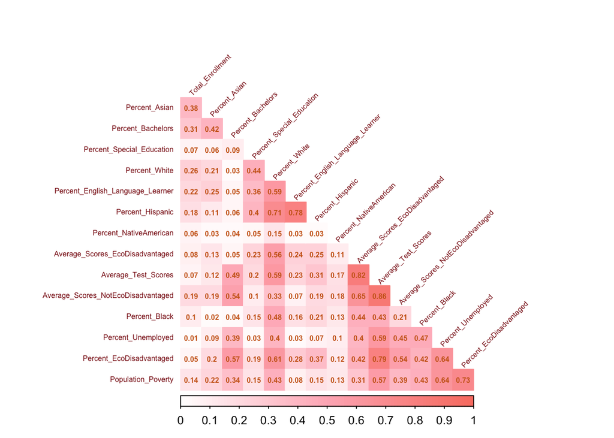

```r
#install.packages("corrplot") #install the correlation package; if already installed, move to the next line

library(corrplot) #call in the package #visualization for the correlation matrix
cor_matrix <- abs(cor(data_corr)) #make the values absolute
cor_matrix_2 <- cor(data_corr)

corrplot(cor_matrix,
         type="lower",
         tl.pos = "ld", #position of text labels #left and diagonal
         tl.cex = .5, #size of the label
         method="color", col=colorRampPalette(c("white","lightpink","salmon"))
         (100),col.lim=c(0,1),
         addCoef.col="chocolate3", #color of numbers
         diag=FALSE,
         tl.col="firebrick4", #color of text label
         tl.srt=45, #numeric rotation
         is.corr = FALSE, #if you include correlation matrix
         order = "hclust", #order results by strength
         number.cex = 0.5, #change size of the
         number.digits = 2) #number of digits after decimal
```

The strongest correlation is 0.86 between average test scores and average test scores for non-economically disadvantaged students. None are at or above 0.90.

## 2.4 Scale variables

Next, let’s scale the variables.

```r
library(psych) #toolbox for psychometric theory
str(data_corr)
```

```
## tibble [933 × 15] (S3: tbl_df/tbl/data.frame)
##  $ Average_Test_Scores               : num [1:933] 0.21221 -0.23448 0.00239 -0.08299 -0.04656 ...
##  $ Average_Scores_EcoDisadvantaged   : num [1:933] -0.049 -0.41 -0.259 -0.265 -0.266 ...
##  $ Average_Scores_NotEcoDisadvantaged: num [1:933] 0.3517 0.0985 0.3419 0.1902 0.1167 ...
##  $ Percent_English_Language_Learner  : num [1:933] 2.104 5.409 2.745 1.848 0.286 ...
##  $ Percent_Special_Education         : num [1:933] 14.3 15 11 16 13.3 ...
##  $ Percent_NativeAmerican            : num [1:933] 5.125 6.783 0.415 37.138 0.42 ...
##  $ Percent_Asian                     : num [1:933] 1.588 1.448 1.528 0.659 0.54 ...
##  $ Percent_Hispanic                  : num [1:933] 2.72 18.64 33.68 6.58 9.01 ...
##  $ Percent_Black                     : num [1:933] 1.62 1.12 8.67 2.56 1.71 ...
##  $ Percent_White                     : num [1:933] 88.9 72 55.7 53.1 88.3 ...
##  $ Percent_EcoDisadvantaged          : num [1:933] 41.3 62.6 56.7 59.9 42.2 ...
##  $ Total_Enrollment                  : num [1:933] 2720 4706 12618 3020 5653 ...
##  $ Percent_Bachelors                 : num [1:933] 26.2 15 21.6 26.5 19.9 ...
##  $ Percent_Unemployed                : num [1:933] 2.43 9.69 4.67 5.47 7.4 ...
##  $ Population_Poverty                : num [1:933] 11.3 15.9 15.7 17.8 12.2 ...
```

```r
scaled_data_pca <- data_corr %>%
  mutate_at(c(1:15), ~(scale(.) %>% as.vector))

str(scaled_data_pca)
```

```
## tibble [933 × 15] (S3: tbl_df/tbl/data.frame)
##  $ Average_Test_Scores               : num [1:933] 1.1793 -0.9861 0.1621 -0.2517 -0.0751 ...
##  $ Average_Scores_EcoDisadvantaged   : num [1:933] 1.58 -0.669 0.275 0.238 0.231 ...
##  $ Average_Scores_NotEcoDisadvantaged: num [1:933] 0.333 -1.133 0.277 -0.602 -1.028 ...
##  $ Percent_English_Language_Learner  : num [1:933] -0.47964 0.00723 -0.38518 -0.51724 -0.74737 ...
##  $ Percent_Special_Education         : num [1:933] 0.28648 0.51229 -0.69493 0.78574 0.00198 ...
##  $ Percent_NativeAmerican            : num [1:933] 0.513 0.779 -0.244 5.657 -0.244 ...
##  $ Percent_Asian                     : num [1:933] -0.127 -0.169 -0.145 -0.406 -0.442 ...
##  $ Percent_Hispanic                  : num [1:933] -0.703 0.096 0.851 -0.509 -0.387 ...
##  $ Percent_Black                     : num [1:933] -0.627 -0.658 -0.198 -0.57 -0.622 ...
##  $ Percent_White                     : num [1:933] 0.915 0.195 -0.497 -0.61 0.889 ...
##  $ Percent_EcoDisadvantaged          : num [1:933] -0.999 0.553 0.128 0.359 -0.935 ...
##  $ Total_Enrollment                  : num [1:933] -0.327 -0.294 -0.162 -0.322 -0.278 ...
##  $ Percent_Bachelors                 : num [1:933] 0.428 -0.927 -0.135 0.457 -0.341 ...
##  $ Percent_Unemployed                : num [1:933] -2.321 1.527 -1.133 -0.708 0.316 ...
##  $ Population_Poverty                : num [1:933] -0.8906 0.0342 -0.0173 0.408 -0.7162 ...
```

```r
psych::describe(scaled_data_pca) #gives you descriptive data like mean, SD, etc.
```

```
##                                    vars   n mean sd median trimmed  mad   min
## Average_Test_Scores                   1 933    0  1   0.08    0.04 0.95 -3.49
## Average_Scores_EcoDisadvantaged       2 933    0  1   0.02    0.02 1.02 -2.92
## Average_Scores_NotEcoDisadvantaged    3 933    0  1   0.07    0.05 0.90 -5.39
## Percent_English_Language_Learner      4 933    0  1  -0.34   -0.21 0.52 -0.79
## Percent_Special_Education             5 933    0  1   0.05    0.04 0.89 -4.00
## Percent_NativeAmerican                6 933    0  1  -0.26   -0.22 0.05 -0.31
## Percent_Asian                         7 933    0  1  -0.29   -0.19 0.24 -0.58
## Percent_Hispanic                      8 933    0  1  -0.40   -0.21 0.48 -0.83
## Percent_Black                         9 933    0  1  -0.46   -0.22 0.32 -0.73
## Percent_White                        10 933    0  1   0.23    0.10 1.05 -2.85
## Percent_EcoDisadvantaged             11 933    0  1  -0.04   -0.04 0.98 -3.14
## Total_Enrollment                     12 933    0  1  -0.28   -0.22 0.08 -0.36
## Percent_Bachelors                    13 933    0  1  -0.21   -0.10 0.92 -1.77
## Percent_Unemployed                   14 933    0  1  -0.07   -0.06 0.87 -2.62
## Population_Poverty                   15 933    0  1  -0.13   -0.09 0.85 -2.25
##                                      max range  skew kurtosis   se
## Average_Test_Scores                 3.10  6.59 -0.35     0.45 0.03
## Average_Scores_EcoDisadvantaged     3.90  6.81 -0.15     0.00 0.03
## Average_Scores_NotEcoDisadvantaged  2.87  8.26 -0.74     2.04 0.03
## Percent_English_Language_Learner    8.06  8.85  2.87    11.98 0.03
## Percent_Special_Education           3.01  7.01 -0.93     3.13 0.03
## Percent_NativeAmerican             12.59 12.90  6.40    50.92 0.03
## Percent_Asian                      17.40 17.98  8.47   115.20 0.03
## Percent_Hispanic                    4.15  4.98  1.99     3.76 0.03
## Percent_Black                       5.12  5.85  2.12     4.70 0.03
## Percent_White                       1.33  4.17 -0.75    -0.25 0.03
## Percent_EcoDisadvantaged            3.17  6.31  0.30     0.00 0.03
## Total_Enrollment                   13.23 13.59  7.06    66.63 0.03
## Percent_Bachelors                   5.00  6.77  1.08     1.41 0.03
## Percent_Unemployed                  5.34  7.96  0.85     2.18 0.03
## Population_Poverty                  4.39  6.64  1.05     1.72 0.03
```

# 3 Visualize the data

In order to analyze a large number of variables, increase comprehension of the data set, and minimize data loss, I conducted a principal component analysis (PCA) (Jolliffe & Cadima, 2016).

```r
#install.packages("factoextra")
library(factoextra) #we use this package to visualize PCA
```

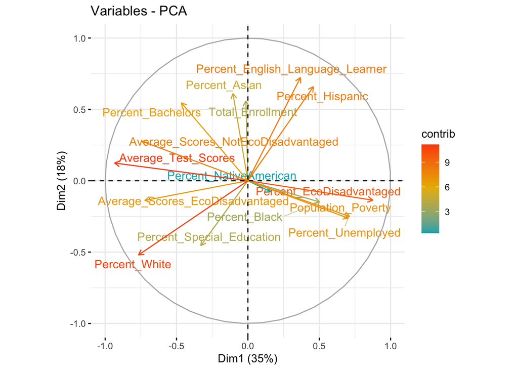

```r
viz_pca <- prcomp(scaled_data_pca, center = TRUE,scale. = TRUE) #run the visualization


#positive correlated variables point to the same side of the plot and negative correlated variables point to opposite sides of the graph

fviz_pca_var(viz_pca,
             col.var = "contrib", # Color by contributions to the PC
             gradient.cols = c("#00AFBB", "#E7B800", "#FC4E07"),
             repel = TRUE #Avoid overlapping text if possible
             )
```

## 3.1 Bartlett’s test

Next, we conduct a Bartlett’s Test of Sphericity to see if the variables are correlated. If the correlation matrix is an identity matrix, the data may not be suitable for factor analysis (Analysis INN, 2020).

```r
cortest.bartlett(scaled_data_pca, 933) #933 equals sample size
```

```
## R was not square, finding R from data
```

```
## $chisq
## [1] 39504.45
##
## $p.value
## [1] 0
##
## $df
## [1] 105
```

```r
# p value was less than .05 so r-matrix is significant and not an identity matrix
```

## 3.2 KMO

We conduct the Kaiser-Meyer-Olkin (KMO) Measure of Sampling Adequacy. The KMO measures the strength of the correlation with values below .5 considered unacceptable and values above .9 considered superb (Analysis INN, 2020).

```r
KMO(scaled_data_pca) #make sure everything is above .50
```

```
## Kaiser-Meyer-Olkin factor adequacy
## Call: KMO(r = scaled_data_pca)
## Overall MSA =  0.48
## MSA for each item =
##                Average_Test_Scores    Average_Scores_EcoDisadvantaged
##                               0.62                               0.55
## Average_Scores_NotEcoDisadvantaged   Percent_English_Language_Learner
##                               0.62                               0.98
##          Percent_Special_Education             Percent_NativeAmerican
##                               0.95                               0.04
##                      Percent_Asian                   Percent_Hispanic
##                               0.13                               0.30
##                      Percent_Black                      Percent_White
##                               0.25                               0.42
##           Percent_EcoDisadvantaged                   Total_Enrollment
##                               0.64                               0.88
##                  Percent_Bachelors                 Percent_Unemployed
##                               0.82                               0.93
##                 Population_Poverty
##                               0.87
```

From this analysis, we see that 5 variables are under .50 (Percent_NativeAmerican, Percent_Hispanic, Percent_White, Percent_Asian, and Percent_Black). We remove the smallest of these variables (Percent_NativeAmerican) and run the KMO again.

```r
str(scaled_data_pca)
```

```
## tibble [933 × 15] (S3: tbl_df/tbl/data.frame)
##  $ Average_Test_Scores               : num [1:933] 1.1793 -0.9861 0.1621 -0.2517 -0.0751 ...
##  $ Average_Scores_EcoDisadvantaged   : num [1:933] 1.58 -0.669 0.275 0.238 0.231 ...
##  $ Average_Scores_NotEcoDisadvantaged: num [1:933] 0.333 -1.133 0.277 -0.602 -1.028 ...
##  $ Percent_English_Language_Learner  : num [1:933] -0.47964 0.00723 -0.38518 -0.51724 -0.74737 ...
##  $ Percent_Special_Education         : num [1:933] 0.28648 0.51229 -0.69493 0.78574 0.00198 ...
##  $ Percent_NativeAmerican            : num [1:933] 0.513 0.779 -0.244 5.657 -0.244 ...
##  $ Percent_Asian                     : num [1:933] -0.127 -0.169 -0.145 -0.406 -0.442 ...
##  $ Percent_Hispanic                  : num [1:933] -0.703 0.096 0.851 -0.509 -0.387 ...
##  $ Percent_Black                     : num [1:933] -0.627 -0.658 -0.198 -0.57 -0.622 ...
##  $ Percent_White                     : num [1:933] 0.915 0.195 -0.497 -0.61 0.889 ...
##  $ Percent_EcoDisadvantaged          : num [1:933] -0.999 0.553 0.128 0.359 -0.935 ...
##  $ Total_Enrollment                  : num [1:933] -0.327 -0.294 -0.162 -0.322 -0.278 ...
##  $ Percent_Bachelors                 : num [1:933] 0.428 -0.927 -0.135 0.457 -0.341 ...
##  $ Percent_Unemployed                : num [1:933] -2.321 1.527 -1.133 -0.708 0.316 ...
##  $ Population_Poverty                : num [1:933] -0.8906 0.0342 -0.0173 0.408 -0.7162 ...
```

```r
draft_scaled_data_pca <- scaled_data_pca[, c(1:5, 7:15)]

str(draft_scaled_data_pca)
```

```
## tibble [933 × 14] (S3: tbl_df/tbl/data.frame)
##  $ Average_Test_Scores               : num [1:933] 1.1793 -0.9861 0.1621 -0.2517 -0.0751 ...
##  $ Average_Scores_EcoDisadvantaged   : num [1:933] 1.58 -0.669 0.275 0.238 0.231 ...
##  $ Average_Scores_NotEcoDisadvantaged: num [1:933] 0.333 -1.133 0.277 -0.602 -1.028 ...
##  $ Percent_English_Language_Learner  : num [1:933] -0.47964 0.00723 -0.38518 -0.51724 -0.74737 ...
##  $ Percent_Special_Education         : num [1:933] 0.28648 0.51229 -0.69493 0.78574 0.00198 ...
##  $ Percent_Asian                     : num [1:933] -0.127 -0.169 -0.145 -0.406 -0.442 ...
##  $ Percent_Hispanic                  : num [1:933] -0.703 0.096 0.851 -0.509 -0.387 ...
##  $ Percent_Black                     : num [1:933] -0.627 -0.658 -0.198 -0.57 -0.622 ...
##  $ Percent_White                     : num [1:933] 0.915 0.195 -0.497 -0.61 0.889 ...
##  $ Percent_EcoDisadvantaged          : num [1:933] -0.999 0.553 0.128 0.359 -0.935 ...
##  $ Total_Enrollment                  : num [1:933] -0.327 -0.294 -0.162 -0.322 -0.278 ...
##  $ Percent_Bachelors                 : num [1:933] 0.428 -0.927 -0.135 0.457 -0.341 ...
##  $ Percent_Unemployed                : num [1:933] -2.321 1.527 -1.133 -0.708 0.316 ...
##  $ Population_Poverty                : num [1:933] -0.8906 0.0342 -0.0173 0.408 -0.7162 ...
```

```r
KMO(draft_scaled_data_pca) #make sure everything is above .50 #Percent_Asian and Percent_Black are still below 0.50 so let's remove the smaller of these two variables (Percent_Black) and run the KMO again
```

```
## Kaiser-Meyer-Olkin factor adequacy
## Call: KMO(r = draft_scaled_data_pca)
## Overall MSA =  0.65
## MSA for each item =
##                Average_Test_Scores    Average_Scores_EcoDisadvantaged
##                               0.62                               0.54
## Average_Scores_NotEcoDisadvantaged   Percent_English_Language_Learner
##                               0.61                               0.91
##          Percent_Special_Education                      Percent_Asian
##                               0.91                               0.49
##                   Percent_Hispanic                      Percent_Black
##                               0.50                               0.45
##                      Percent_White           Percent_EcoDisadvantaged
##                               0.63                               0.64
##                   Total_Enrollment                  Percent_Bachelors
##                               0.81                               0.79
##                 Percent_Unemployed                 Population_Poverty
##                               0.92                               0.86
```

```r
final_scaled_data_pca <- draft_scaled_data_pca[, c(1:7, 9:14)]

str(final_scaled_data_pca) #check to make sure Percent_Black is removed from the analysis
```

```
## tibble [933 × 13] (S3: tbl_df/tbl/data.frame)
##  $ Average_Test_Scores               : num [1:933] 1.1793 -0.9861 0.1621 -0.2517 -0.0751 ...
##  $ Average_Scores_EcoDisadvantaged   : num [1:933] 1.58 -0.669 0.275 0.238 0.231 ...
##  $ Average_Scores_NotEcoDisadvantaged: num [1:933] 0.333 -1.133 0.277 -0.602 -1.028 ...
##  $ Percent_English_Language_Learner  : num [1:933] -0.47964 0.00723 -0.38518 -0.51724 -0.74737 ...
##  $ Percent_Special_Education         : num [1:933] 0.28648 0.51229 -0.69493 0.78574 0.00198 ...
##  $ Percent_Asian                     : num [1:933] -0.127 -0.169 -0.145 -0.406 -0.442 ...
##  $ Percent_Hispanic                  : num [1:933] -0.703 0.096 0.851 -0.509 -0.387 ...
##  $ Percent_White                     : num [1:933] 0.915 0.195 -0.497 -0.61 0.889 ...
##  $ Percent_EcoDisadvantaged          : num [1:933] -0.999 0.553 0.128 0.359 -0.935 ...
##  $ Total_Enrollment                  : num [1:933] -0.327 -0.294 -0.162 -0.322 -0.278 ...
##  $ Percent_Bachelors                 : num [1:933] 0.428 -0.927 -0.135 0.457 -0.341 ...
##  $ Percent_Unemployed                : num [1:933] -2.321 1.527 -1.133 -0.708 0.316 ...
##  $ Population_Poverty                : num [1:933] -0.8906 0.0342 -0.0173 0.408 -0.7162 ...
```

```r
KMO(final_scaled_data_pca) #everything is above .50
```

```
## Kaiser-Meyer-Olkin factor adequacy
## Call: KMO(r = final_scaled_data_pca)
## Overall MSA =  0.69
## MSA for each item =
##                Average_Test_Scores    Average_Scores_EcoDisadvantaged
##                               0.61                               0.52
## Average_Scores_NotEcoDisadvantaged   Percent_English_Language_Learner
##                               0.60                               0.75
##          Percent_Special_Education                      Percent_Asian
##                               0.90                               0.73
##                   Percent_Hispanic                      Percent_White
##                               0.68                               0.83
##           Percent_EcoDisadvantaged                   Total_Enrollment
##                               0.62                               0.79
##                  Percent_Bachelors                 Percent_Unemployed
##                               0.79                               0.89
##                 Population_Poverty
##                               0.85
```

Overall MSA = 0.69 so we are good to move on to the next step.